# Lab4

Jonathan Kim

2/24/2022

Download this dataset: http://afodor.github.io/classes/stats2015/longitdunalRNASeqData.zip

(right-click in the browser and say “save as…”)

Each row in the spreadsheet represents a different gene in an RNA-seq experiment. The samples are E. Coli derived from two different mice under identical conditions (i.e. biological replicates).

1. Read the dataset into R using commands something like…

setwd(“C:\classes\Advanced_Stats_Spring2022\Lab4_HW1”)

myT <- read.table(“nc101_scaff_dataCounts.txt”,header=TRUE,row.names=1)

```r
rm(list=ls())
myT<- read.table("./longitdunalRNASeqData/nc101_scaff_dataCounts.txt",header=TRUE,row.names=1)
```

2. On a log10-log10 scale, show a plot of the counts for the two samples “D2_01” and “D2_02”.

Qualitatively, do the biological replicates appear to have similar patterns of gene expression?

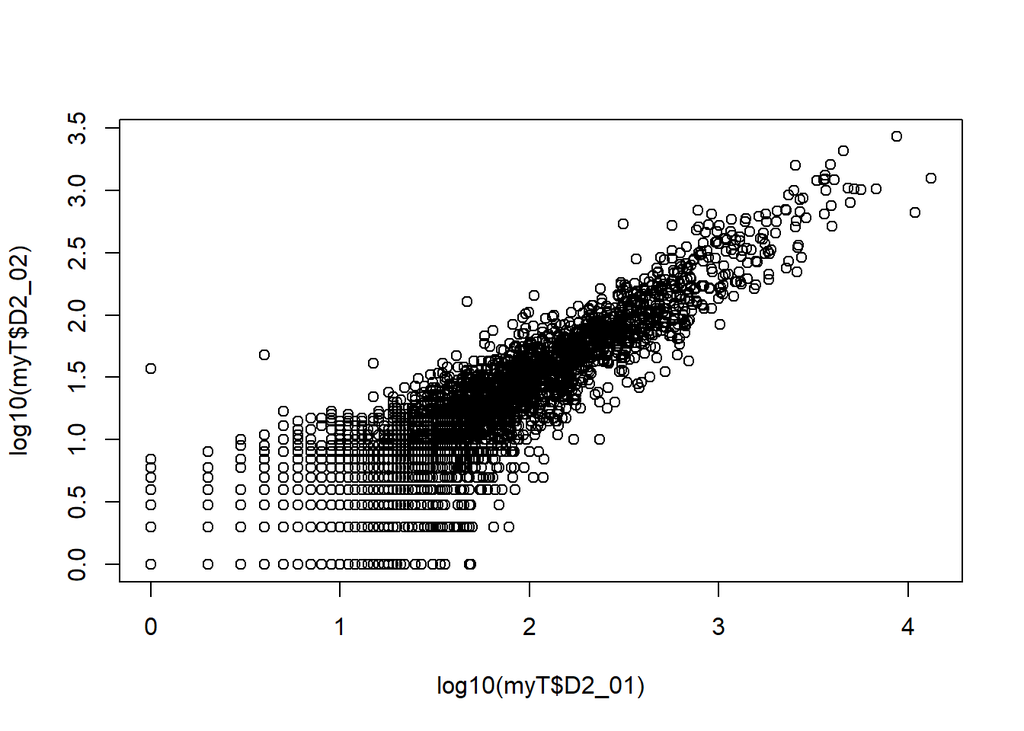

```r
plot(log10(myT$D2_01),log10(myT$D2_02))
```

Qualitatively, the biological replicates appear to roughly have similar patterns of gene expression.

3. On a log10-log10 scale, plot the variance of all genes (across all samples) vs. the mean (across all genes) with a red line on your graph representing the identity line. Does the mean equal the variance for these samples?  
   (The commands apply(myT, 1, mean) and apply(myT, 1, var) will be of some use).

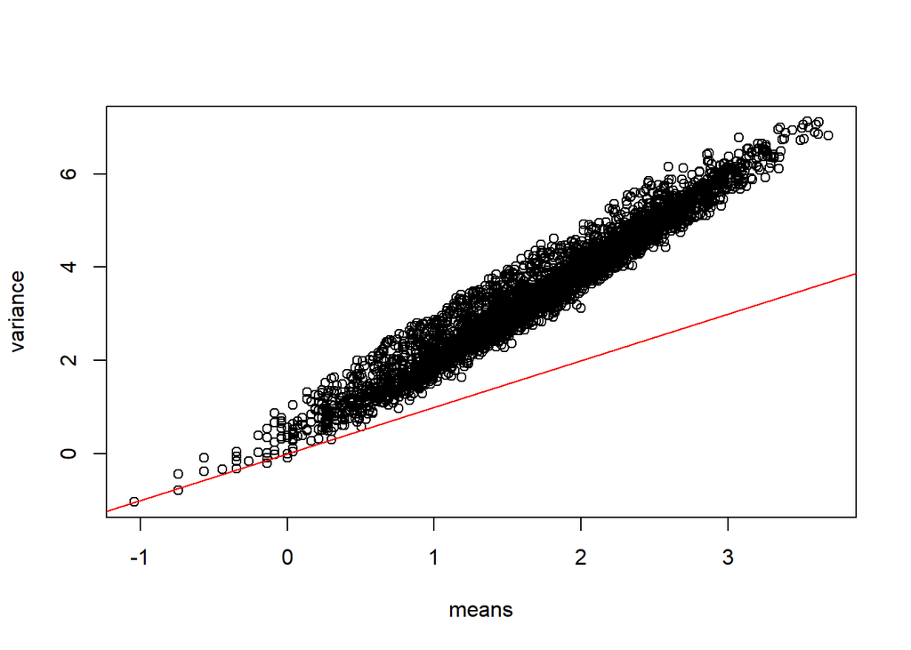

```r
variance <- log10(apply(myT,1,var))
means <- log10(apply(myT,1,mean))
plot(means,variance)
lines(c(-5,5),c(-5,5),col="red")
```

No, they are not equal for these samples.

4. Consider the first gene in the spreadsheet (e.g. NC101_00003). Make a two by two contingency table: columns: Sequences in D2_01, Sequences in D2_02 rows: Assigned to NC101_00003, Not assigned to NC101_00003

use the two sided fisher.test to generate a p-value for the null hypothesis that the columns and rows of the contingency table are independent.

```r
sums01 <- apply(myT,2,sum)
m <- matrix(c(myT[1,1], myT[1,2], sums01[1]-myT[1,1], sums01[2]-myT[1,2] ), nrow=2)
test <- fisher.test(m,alternative="two.sided")
pValue <- test$p.value
pValue
```

```
## [1] 1.670017e-11
```

5. Now generate a p-value for all the genes in the spreadsheet from the Fisher test. Plot out those p-values in a histogram. Are they uniformly distributed? Would you expect them to be? Are the p-values more significant, less significant or what we would expect under a uniform distribution?

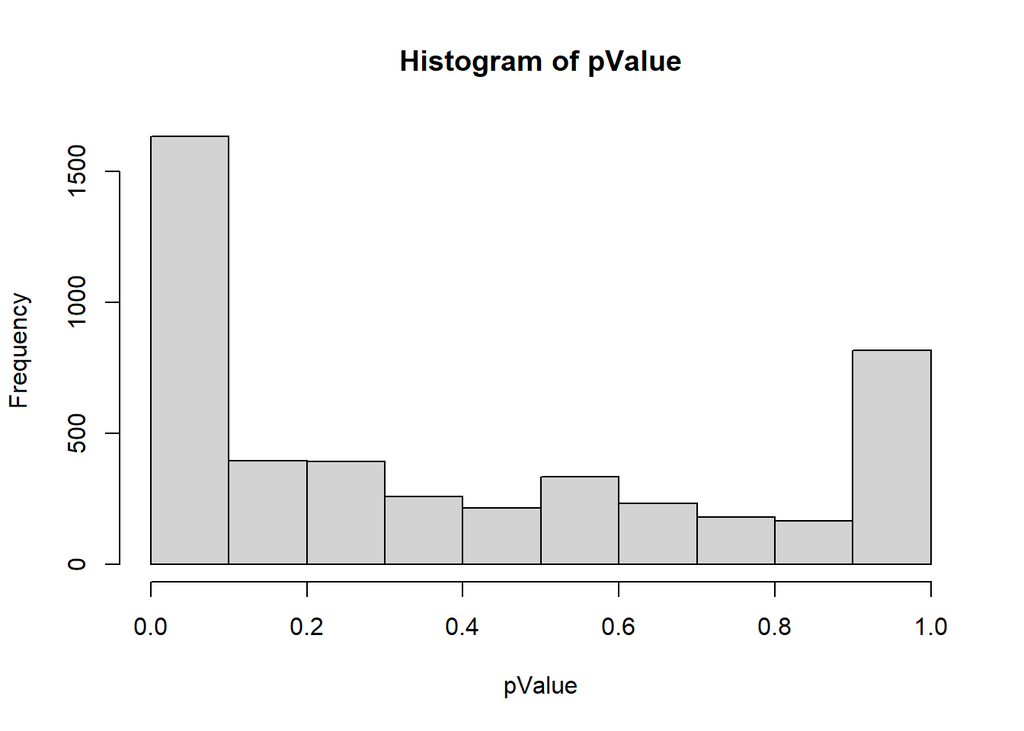

```r
rm(list=ls())
myT<- read.table("./longitdunalRNASeqData/nc101_scaff_dataCounts.txt",header=TRUE,row.names=1)
sums01 <- apply(myT,2,sum)

pValue <- vector();
for (i in 1:nrow(myT)) {
  m <- matrix(c(myT[i,1], myT[i,2], sums01[1]-myT[i,1], sums01[2]-myT[i,2] ), nrow=2)
  test <- fisher.test(m)
  pValue[i] <- test$p.value
}
hist(pValue)
```

They were not uniformly distributed. No, I wouldn’t expect them to be because these are two different mice that could have drastically different microbiomes. There is a high frequency of significance, but also has a high frequency of no significance. They are generally more significant than what we would expect under an uniform distribution.

(5b) How does the p-value distribution change if you remove low abundance genes (with for example myT <- myT[(myT$D2_01 + myT$D2_02 > 50),]

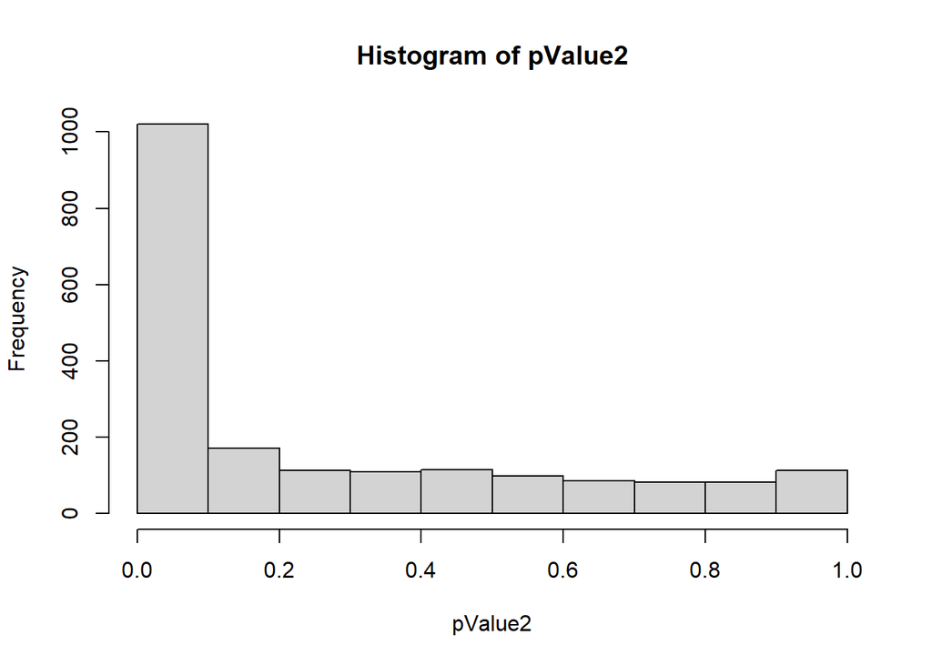

```r
myT2 <- myT[(myT$D2_01 + myT$D2_02 > 50),]
sums02 <- apply(myT2,2,sum)

pValue2 <- vector();
for (i in 1:nrow(myT2)) {
  m <- matrix(c(myT2[i,1], myT2[i,2], sums02[1]-myT2[i,1], sums02[2]-myT2[i,2] ), nrow=2)
  test <- fisher.test(m)
  pValue2[i] <- test$p.value
}
hist(pValue2)
```

The frequency of lower p-values is still high with the higher p-value frequency decreased. It shifts to become more significant.

6. Add 1 to every value in the table ( with something like myT = myT + 1 ). This is called adding a pseudo-count. Now consider the first gene (NC101_00003 ) again. From the first experiment, calculate

expected frequency = p = (# Assigned to NC101_00003 in D2_01)/total # of sequences in D2_01)

Now use poisson.test to assign a p-value for the null hypothesis that value of p derived from D2_01 could have produced the number of reads observed for this gene in D2_02 .

```r
myT <- read.table("./longitdunalRNASeqData/nc101_scaff_dataCounts.txt",header=TRUE,row.names=1)
myT = myT + 1
sums01 <- apply(myT,2,sum)
freq1 <- myT[1,1]/sums01[1]
numMarked <- myT[1,2]
(ptest = poisson.test(numMarked, sums01[2],freq1,alternative="two.sided"))
```

```
##
##  Exact Poisson test
##
## data:  numMarked time base: sums01[2]
## number of events = 30, time base = 162959, p-value = 1.139e-13
## alternative hypothesis: true event rate is not equal to 0.0005640621
## 95 percent confidence interval:
##  0.0001242084 0.0002628076
## sample estimates:
##   event rate
## 0.0001840954
```

```r
ptest$p.value
```

```
##        D2_01
## 1.139341e-13
```

7. Repeat the calculation in (6) for every gene in the spreadsheet. Graph these p-values against the p-values produced in (5) on a log10-log10 plot. How well do they agree?

(Note: since the mean does not equal the variance, the models make assumptions that are not supported by the data! Also, with n=1 in both conditions, our sample size is small and we would want to be very careful about putting too much weight in any conclusions we draw from such a small sample size…)

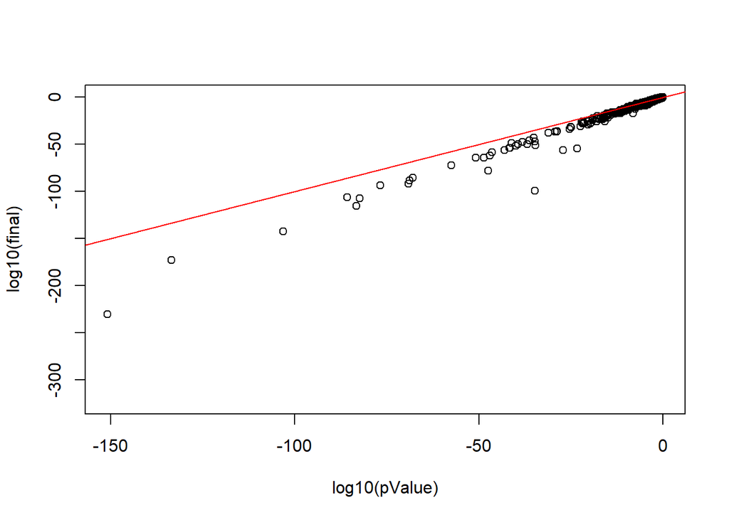

```r
myT <- read.table("./longitdunalRNASeqData/nc101_scaff_dataCounts.txt",header=TRUE,row.names=1)
myT = myT + 1
sums01 <- apply(myT,2,sum)
final <- vector();
for (i in 1:nrow(myT)) {
  freq1 <- myT[i,1]/sums01[1]
  #print(freq1)
  numMarked <- myT[i,2]
  final[i] <- poisson.test(numMarked, sums01[2],r=freq1)$p.value
}
plot(log10(pValue),log10(final))
lines(c(-400,400),c(-400,400),col="red")
```

They mostly agree at around higher values.